[figure not shown]

# Project- Tharun Prabhakar,Sumit Kumar, Niranjan Kumar

## Midterm project: Equity Portfolio Management Group: Tharun Prabhakar, Sumit Kumar, Niranjan Kumar

### Data Preparation

Download the historial daily data of the entire 2018 for the 10 stocks

```python
universe = ['IBM', 'MSFT', 'GOOG', 'AAPL', 'AMZN', 'META', 'NFLX', 'TSLA', 'ORCL', 'SAP']
```

You should have 10 csv files on your disk now. IBM.csv, MSFT.csv, etc. We call the 10 stocks "universe" which is the entire stock market you can trade.

[figure not shown]

### Retrieve the "Close" and "Adj Close" values for each stock

You will create a dataframe where there are 20 columns for the 10 stocks, each row is the "Close" and "Adj Close" prices for the 10 stocks on each day, in the order of the business days in 2018. Assume all buy/sell on the "Close" prices and there is no transaction cost.

### You start to manage 5 million dollars fund on Jan 02, 2018

You have a strategy to manage the fund.

import pandas as pd

import numpy as np

import matplotlib.pyplot as plt

import seaborn as sb

from warnings import filterwarnings

from matplotlib.lines import Line2D

filterwarnings('ignore')

np.set_printoptions(precision=3)

np.set_printoptions(suppress=True)

IBM=pd.read_csv("IBM.csv")[["Date","Close","Adj Close"]]

MSFT=pd.read_csv("MSFT.csv")[["Date","Close","Adj Close"]]

GOOG=pd.read_csv("GOOG.csv")[["Date","Close","Adj Close"]]

AAPL=pd.read_csv("AAPL.csv")[["Date","Close","Adj Close"]]

AMZN=pd.read_csv("AMZN.csv")[["Date","Close","Adj Close"]]

META=pd.read_csv("META.csv")[["Date","Close","Adj Close"]]

NFLX=pd.read_csv("NFLX.csv")[["Date","Close","Adj Close"]]

TSLA=pd.read_csv("TSLA.csv")[["Date","Close","Adj Close"]]

ORCL=pd.read_csv("ORCL.csv")[["Date","Close","Adj Close"]]

SAP=pd.read_csv("SAP.csv")[["Date","Close","Adj Close"]]

universe = [IBM, MSFT, GOOG, AAPL, AMZN, META, NFLX, TSLA, ORCL, SAP]

for df in universe:

df['Close Ratio']=[0 if i==0 else df.Close[i-1]/df.Close[i] for i in range(len(df.Close))]

df['Adj Close Ratio']=[0 if i==0 else df['Adj Close'][i-1]/df['Adj Close'][i] for i in range(len(df['Adj Close']))]

df['Ratio Difference']=round(np.abs(df['Close Ratio']-df['Adj Close Ratio']),4)

df["Dividend"]=round(df['Ratio Difference']*df['Close'],6)

df.drop(['Close Ratio','Adj Close Ratio','Ratio Difference'],inplace=True,axis=1)

def data(df):

return df.head()

def rename(x,df):

return df.rename(columns={'Close':x+'_Close','Adj Close':x+'_Adj_Close','Dividend':x+'_Dividend'},inplace=True)

names = ['IBM', 'MSFT', 'GOOG', 'AAPL', 'AMZN', 'META', 'NFLX', 'TSLA', 'ORCL', 'SAP']

IBM.Date=pd.to_datetime(IBM.Date)

MSFT.Date=pd.to_datetime(IBM.Date)

GOOG.Date=pd.to_datetime(IBM.Date)

AAPL.Date=pd.to_datetime(IBM.Date)

AMZN.Date=pd.to_datetime(IBM.Date)

META.Date=pd.to_datetime(IBM.Date)

NFLX.Date=pd.to_datetime(IBM.Date)

TSLA.Date=pd.to_datetime(IBM.Date)

ORCL.Date=pd.to_datetime(IBM.Date)

SAP.Date=pd.to_datetime(IBM.Date)

for i,j in zip(universe,names):

rename(j,i)

data(IBM)

|  | Date | IBM_Close | IBM_Adj_Close | IBM_Dividend |
| --- | --- | --- | --- | --- |
| 0 | 2018-01-02 | 147.466537 | 111.800133 | 0.0 |
| 1 | 2018-01-03 | 151.520081 | 114.873306 | 0.0 |
| 2 | 2018-01-04 | 154.588913 | 117.199913 | 0.0 |
| 3 | 2018-01-05 | 155.344162 | 117.772476 | 0.0 |
| 4 | 2018-01-08 | 156.281067 | 118.482796 | 0.0 |

data(MSFT)

|  | Date | MSFT_Close | MSFT_Adj_Close | MSFT_Dividend |
| --- | --- | --- | --- | --- |
| 0 | 2018-01-02 | 85.949997 | 80.391853 | 0.0 |
| 1 | 2018-01-03 | 86.349998 | 80.765961 | 0.0 |
| 2 | 2018-01-04 | 87.110001 | 81.476837 | 0.0 |
| 3 | 2018-01-05 | 88.190002 | 82.486992 | 0.0 |
| 4 | 2018-01-08 | 88.279999 | 82.571167 | 0.0 |

data(GOOG)

|  | Date | GOOG_Close | GOOG_Adj_Close | GOOG_Dividend |
| --- | --- | --- | --- | --- |
| 0 | 2018-01-02 | 53.250000 | 53.250000 | 0.0 |
| 1 | 2018-01-03 | 54.124001 | 54.124001 | 0.0 |
| 2 | 2018-01-04 | 54.320000 | 54.320000 | 0.0 |
| 3 | 2018-01-05 | 55.111500 | 55.111500 | 0.0 |
| 4 | 2018-01-08 | 55.347000 | 55.347000 | 0.0 |

data(AAPL)

|  | Date | AAPL_Close | AAPL_Adj_Close | AAPL_Dividend |
| --- | --- | --- | --- | --- |
| 0 | 2018-01-02 | 43.064999 | 40.776524 | 0.0 |
| 1 | 2018-01-03 | 43.057499 | 40.769421 | 0.0 |
| 2 | 2018-01-04 | 43.257500 | 40.958801 | 0.0 |
| 3 | 2018-01-05 | 43.750000 | 41.425121 | 0.0 |
| 4 | 2018-01-08 | 43.587502 | 41.271267 | 0.0 |

data(AMZN)

|  | Date | AMZN_Close | AMZN_Adj_Close | AMZN_Dividend |
| --- | --- | --- | --- | --- |
| 0 | 2018-01-02 | 59.450500 | 59.450500 | 0.0 |
| 1 | 2018-01-03 | 60.209999 | 60.209999 | 0.0 |
| 2 | 2018-01-04 | 60.479500 | 60.479500 | 0.0 |
| 3 | 2018-01-05 | 61.457001 | 61.457001 | 0.0 |
| 4 | 2018-01-08 | 62.343498 | 62.343498 | 0.0 |

data(META)

|  | Date | META_Close | META_Adj_Close | META_Dividend |
| --- | --- | --- | --- | --- |
| 0 | 2018-01-02 | 181.419998 | 181.419998 | 0.0 |
| 1 | 2018-01-03 | 184.669998 | 184.669998 | 0.0 |
| 2 | 2018-01-04 | 184.330002 | 184.330002 | 0.0 |
| 3 | 2018-01-05 | 186.850006 | 186.850006 | 0.0 |
| 4 | 2018-01-08 | 188.279999 | 188.279999 | 0.0 |

data(NFLX)

|  | Date | NFLX_Close | NFLX_Adj_Close | NFLX_Dividend |
| --- | --- | --- | --- | --- |
| 0 | 2018-01-02 | 201.070007 | 201.070007 | 0.0 |
| 1 | 2018-01-03 | 205.050003 | 205.050003 | 0.0 |
| 2 | 2018-01-04 | 205.630005 | 205.630005 | 0.0 |
| 3 | 2018-01-05 | 209.990005 | 209.990005 | 0.0 |
| 4 | 2018-01-08 | 212.050003 | 212.050003 | 0.0 |

data(TSLA)

|  | Date | TSLA_Close | TSLA_Adj_Close | TSLA_Dividend |
| --- | --- | --- | --- | --- |
| 0 | 2018-01-02 | 21.368668 | 21.368668 | 0.0 |
| 1 | 2018-01-03 | 21.150000 | 21.150000 | 0.0 |
| 2 | 2018-01-04 | 20.974667 | 20.974667 | 0.0 |
| 3 | 2018-01-05 | 21.105333 | 21.105333 | 0.0 |
| 4 | 2018-01-08 | 22.427334 | 22.427334 | 0.0 |

data(ORCL)

|  | Date | ORCL_Close | ORCL_Adj_Close | ORCL_Dividend |
| --- | --- | --- | --- | --- |
| 0 | 2018-01-02 | 46.630001 | 42.437176 | 0.0 |
| 1 | 2018-01-03 | 47.709999 | 43.420063 | 0.0 |
| 2 | 2018-01-04 | 48.180000 | 43.847794 | 0.0 |
| 3 | 2018-01-05 | 48.470001 | 44.111725 | 0.0 |
| 4 | 2018-01-08 | 48.980000 | 44.575863 | 0.0 |

data(SAP)

|  | Date | SAP_Close | SAP_Adj_Close | SAP_Dividend |
| --- | --- | --- | --- | --- |
| 0 | 2018-01-02 | 112.389999 | 101.210297 | 0.0 |
| 1 | 2018-01-03 | 113.309998 | 102.038773 | 0.0 |
| 2 | 2018-01-04 | 115.050003 | 103.605690 | 0.0 |
| 3 | 2018-01-05 | 116.330002 | 104.758369 | 0.0 |
| 4 | 2018-01-08 | 114.800003 | 103.380562 | 0.0 |

## Creating Final Dataset

universe = [IBM, MSFT, GOOG, AAPL, AMZN, META, NFLX, TSLA, ORCL, SAP]

df=IBM.copy()

for i in universe[1:]:

df=df.merge(i,how='outer',on='Date')

df.tail()

|  | Date | IBM_Close | IBM_Adj_Close | IBM_Dividend | MSFT_Close | MSFT_Adj_Close | MSFT_Dividend | GOOG_Close | GOOG_Adj_Close | GOOG_Dividend | ... | NFLX_Dividend | TSLA_Close | TSLA_Adj_Close | TSLA_Dividend | ORCL_Close | ORCL_Adj_Close | ORCL_Dividend | SAP_Close | SAP_Adj_Close | SAP_Dividend |
| --- | --- | --- | --- | --- | --- | --- | --- | --- | --- | --- | --- | --- | --- | --- | --- | --- | --- | --- | --- | --- | --- |
| 245 | 2018-12-21 | 106.061188 | 84.046196 | 0.0 | 98.230003 | 93.468269 | 0.0 | 48.977001 | 48.977001 | 0.0 | ... | 0.0 | 21.318001 | 21.318001 | 0.0 | 44.000000 | 40.687527 | 0.0 | 96.139999 | 87.901962 | 0.0 |
| 246 | 2018-12-24 | 102.839386 | 81.493156 | 0.0 | 94.129997 | 89.566994 | 0.0 | 48.811001 | 48.811001 | 0.0 | ... | 0.0 | 19.692667 | 19.692667 | 0.0 | 42.689999 | 39.476147 | 0.0 | 95.000000 | 86.859650 | 0.0 |
| 247 | 2018-12-26 | 106.491394 | 84.387115 | 0.0 | 100.559998 | 95.685303 | 0.0 | 51.973000 | 51.973000 | 0.0 | ... | 0.0 | 21.739332 | 21.739332 | 0.0 | 44.590000 | 41.233105 | 0.0 | 98.379997 | 89.950020 | 0.0 |
| 248 | 2018-12-27 | 108.776291 | 86.197746 | 0.0 | 101.180000 | 96.275261 | 0.0 | 52.194000 | 52.194000 | 0.0 | ... | 0.0 | 21.075333 | 21.075333 | 0.0 | 44.970001 | 41.584507 | 0.0 | 98.989998 | 90.507744 | 0.0 |
| 249 | 2018-12-28 | 108.059273 | 85.629555 | 0.0 | 100.389999 | 95.523537 | 0.0 | 51.854000 | 51.854000 | 0.0 | ... | 0.0 | 22.257999 | 22.257999 | 0.0 | 44.820000 | 41.445786 | 0.0 | 99.199997 | 90.699760 | 0.0 |

5 rows × 31 columns

df.head()

|  | Date | IBM_Close | IBM_Adj_Close | IBM_Dividend | MSFT_Close | MSFT_Adj_Close | MSFT_Dividend | GOOG_Close | GOOG_Adj_Close | GOOG_Dividend | ... | NFLX_Dividend | TSLA_Close | TSLA_Adj_Close | TSLA_Dividend | ORCL_Close | ORCL_Adj_Close | ORCL_Dividend | SAP_Close | SAP_Adj_Close | SAP_Dividend |
| --- | --- | --- | --- | --- | --- | --- | --- | --- | --- | --- | --- | --- | --- | --- | --- | --- | --- | --- | --- | --- | --- |
| 0 | 2018-01-02 | 147.466537 | 111.800133 | 0.0 | 85.949997 | 80.391853 | 0.0 | 53.250000 | 53.250000 | 0.0 | ... | 0.0 | 21.368668 | 21.368668 | 0.0 | 46.630001 | 42.437176 | 0.0 | 112.389999 | 101.210297 | 0.0 |
| 1 | 2018-01-03 | 151.520081 | 114.873306 | 0.0 | 86.349998 | 80.765961 | 0.0 | 54.124001 | 54.124001 | 0.0 | ... | 0.0 | 21.150000 | 21.150000 | 0.0 | 47.709999 | 43.420063 | 0.0 | 113.309998 | 102.038773 | 0.0 |
| 2 | 2018-01-04 | 154.588913 | 117.199913 | 0.0 | 87.110001 | 81.476837 | 0.0 | 54.320000 | 54.320000 | 0.0 | ... | 0.0 | 20.974667 | 20.974667 | 0.0 | 48.180000 | 43.847794 | 0.0 | 115.050003 | 103.605690 | 0.0 |
| 3 | 2018-01-05 | 155.344162 | 117.772476 | 0.0 | 88.190002 | 82.486992 | 0.0 | 55.111500 | 55.111500 | 0.0 | ... | 0.0 | 21.105333 | 21.105333 | 0.0 | 48.470001 | 44.111725 | 0.0 | 116.330002 | 104.758369 | 0.0 |
| 4 | 2018-01-08 | 156.281067 | 118.482796 | 0.0 | 88.279999 | 82.571167 | 0.0 | 55.347000 | 55.347000 | 0.0 | ... | 0.0 | 22.427334 | 22.427334 | 0.0 | 48.980000 | 44.575863 | 0.0 | 114.800003 | 103.380562 | 0.0 |

5 rows × 31 columns

### Strategy 1: 5 Day Rebalancing Buying-Low

Amount=5000000

Portfolio={'IBM':{'Stocks':1000000//df['IBM_Close'].iloc[0],'Rest':1000000-(1000000//df['IBM_Close'].iloc[0]*df['IBM_Close'].iloc[0])},

'MSFT':{'Stocks':1000000//df['MSFT_Close'].iloc[0],'Rest':1000000-(1000000//df['MSFT_Close'].iloc[0]*df['MSFT_Close'].iloc[0])},

'GOOG':{'Stocks':1000000//df['GOOG_Close'].iloc[0],'Rest':1000000-(1000000//df['GOOG_Close'].iloc[0]*df['GOOG_Close'].iloc[0])},

'AAPL':{'Stocks':1000000//df['AAPL_Close'].iloc[0],'Rest':1000000-(1000000//df['AAPL_Close'].iloc[0]*df['AAPL_Close'].iloc[0])},

'AMZN':{'Stocks':1000000//df['AMZN_Close'].iloc[0],'Rest':1000000-(1000000//df['AMZN_Close'].iloc[0]*df['AMZN_Close'].iloc[0])},

'META':{'Stocks':0,'Rest':0},

'NFLX':{'Stocks':0,'Rest':0},

'TSLA':{'Stocks':0,'Rest':0},

'ORCL':{'Stocks':0,'Rest':0},

'SAP':{'Stocks':0,'Rest':0}

}

Overall_MTM=[]

Overall_MTM+=[5000000]

Overall_MTM

d=[]

l=0

l1=0

names = ['IBM', 'MSFT', 'GOOG', 'AAPL', 'AMZN', 'META', 'NFLX', 'TSLA', 'ORCL', 'SAP']

Stocks=['IBM','MSFT','GOOG','AAPL','AMZN']

for i in range(1,len(df)):

s=0

l+=1

for j in names:

if j in Stocks:

mtm=((Portfolio[j]['Stocks']*df[j+'_Close'][i])+(Portfolio[j]['Rest'])+(Portfolio[j]['Stocks']*df[j+'_Dividend'][i]))

s+=mtm

Overall_MTM+=[s]

if l%5==0:

Percent_change={'IBM':0,'MSFT':0,"GOOG":0,'AAPL':0,'AMZN':0,'META':0,'NFLX':0, 'TSLA':0, 'ORCL':0, 'SAP':0}

for j in names:

Percent_change[j]=round(((df[j+'_Adj_Close'][i]-df[j+'_Adj_Close'][i-5])/df[j+'_Adj_Close'][i-5])*100,3)

Stocks=[i[0] for i in list(sorted(Percent_change.items(), key=lambda x: x[1]))[0:5]]

for j in names:

if j in Stocks:

a=s/5

Portfolio[j]['Stocks']=a//df[j+'_Close'].iloc[i]

Portfolio[j]['Rest']=a-(a//df[j+'_Close'].iloc[i]*df[j+'_Close'].iloc[i])

else:

Portfolio[j]['Stocks']=0

Portfolio[j]['Rest']=0

df1=df.copy()

df1['High_Tech_Index']=(df1.IBM_Close+df1.MSFT_Close+df1.GOOG_Close+df1.AMZN_Close+df1.AAPL_Close+df1.META_Close+

df1.NFLX_Close+df1.TSLA_Close+df1.ORCL_Close+df1.SAP_Close)/10

df1['Overall_MTM']=Overall_MTM

df1['High_Tech_Index_Percent_Change']=[((df1['High_Tech_Index'][i]-df1['High_Tech_Index'][0])/df1['High_Tech_Index'][0])*100 if i>0 else 0

for i in range(len(df1))]

df1['Overall_MTM_Percent_Change']=[((df1['Overall_MTM'][i]-df1['Overall_MTM'][0])/df1['Overall_MTM'][0])*100 if i>0 else 0

for i in range(len(df1))]

df1.head(11)

|  | Date | IBM_Close | IBM_Adj_Close | IBM_Dividend | MSFT_Close | MSFT_Adj_Close | MSFT_Dividend | GOOG_Close | GOOG_Adj_Close | GOOG_Dividend | ... | ORCL_Close | ORCL_Adj_Close | ORCL_Dividend | SAP_Close | SAP_Adj_Close | SAP_Dividend | High_Tech_Index | Overall_MTM | High_Tech_Index_Percent_Change | Overall_MTM_Percent_Change |
| --- | --- | --- | --- | --- | --- | --- | --- | --- | --- | --- | --- | --- | --- | --- | --- | --- | --- | --- | --- | --- | --- |
| 0 | 2018-01-02 | 147.466537 | 111.800133 | 0.0 | 85.949997 | 80.391853 | 0.0 | 53.250000 | 53.250000 | 0.0 | ... | 46.630001 | 42.437176 | 0.000000 | 112.389999 | 101.210297 | 0.0 | 95.206071 | 5.000000e+06 | 0.000000 | 0.000000 |
| 1 | 2018-01-03 | 151.520081 | 114.873306 | 0.0 | 86.349998 | 80.765961 | 0.0 | 54.124001 | 54.124001 | 0.0 | ... | 47.709999 | 43.420063 | 0.000000 | 113.309998 | 102.038773 | 0.0 | 96.715158 | 5.061154e+06 | 1.585074 | 1.223084 |
| 2 | 2018-01-04 | 154.588913 | 117.199913 | 0.0 | 87.110001 | 81.476837 | 0.0 | 54.320000 | 54.320000 | 0.0 | ... | 48.180000 | 43.847794 | 0.000000 | 115.050003 | 103.605690 | 0.0 | 97.392059 | 5.103664e+06 | 2.296060 | 2.073270 |
| 3 | 2018-01-05 | 155.344162 | 117.772476 | 0.0 | 88.190002 | 82.486992 | 0.0 | 55.111500 | 55.111500 | 0.0 | ... | 48.470001 | 44.111725 | 0.000000 | 116.330002 | 104.758369 | 0.0 | 98.659801 | 5.164091e+06 | 3.627637 | 3.281811 |
| 4 | 2018-01-08 | 156.281067 | 118.482796 | 0.0 | 88.279999 | 82.571167 | 0.0 | 55.347000 | 55.347000 | 0.0 | ... | 48.980000 | 44.575863 | 0.000000 | 114.800003 | 103.380562 | 0.0 | 99.237640 | 5.187051e+06 | 4.234572 | 3.741018 |
| 5 | 2018-01-09 | 156.625244 | 118.743706 | 0.0 | 88.220001 | 82.515060 | 0.0 | 55.313000 | 55.313000 | 0.0 | ... | 49.060001 | 44.822540 | 0.191334 | 114.160004 | 102.804222 | 0.0 | 98.902174 | 5.192835e+06 | 3.882214 | 3.856703 |
| 6 | 2018-01-10 | 156.959854 | 118.997383 | 0.0 | 87.820000 | 82.140900 | 0.0 | 55.130501 | 55.130501 | 0.0 | ... | 48.799999 | 44.585003 | 0.000000 | 112.870003 | 101.642548 | 0.0 | 99.054935 | 5.172560e+06 | 4.042667 | 3.451208 |
| 7 | 2018-01-11 | 156.978973 | 119.011909 | 0.0 | 88.080002 | 82.384109 | 0.0 | 55.276001 | 55.276001 | 0.0 | ... | 48.950001 | 44.722042 | 0.000000 | 109.639999 | 98.733833 | 0.0 | 99.411899 | 5.154481e+06 | 4.417605 | 3.089610 |
| 8 | 2018-01-12 | 155.965576 | 118.243591 | 0.0 | 89.599998 | 83.805824 | 0.0 | 56.112999 | 56.112999 | 0.0 | ... | 49.509998 | 45.233669 | 0.000000 | 110.129997 | 99.175095 | 0.0 | 99.386573 | 5.156894e+06 | 4.391004 | 3.137885 |
| 9 | 2018-01-16 | 156.644363 | 118.758202 | 0.0 | 88.349998 | 82.636642 | 0.0 | 56.088001 | 56.088001 | 0.0 | ... | 49.590000 | 45.306770 | 0.000000 | 110.680000 | 99.670380 | 0.0 | 99.323353 | 5.135934e+06 | 4.324600 | 2.718687 |
| 10 | 2018-01-17 | 161.233276 | 122.237259 | 0.0 | 90.139999 | 84.310890 | 0.0 | 56.598999 | 56.598999 | 0.0 | ... | 50.270000 | 45.928036 | 0.000000 | 111.190002 | 100.129669 | 0.0 | 99.720128 | 5.184209e+06 | 4.741355 | 3.684176 |

11 rows × 35 columns

plt.plot(df1['Date'], df1['Overall_MTM_Percent_Change'],color='red' ,label='Overall MTM')

plt.plot(df1['Date'], df1['High_Tech_Index_Percent_Change'], color='blue', label='High Tech Index')

plt.xlabel('Date')

plt.legend()

plt.show()

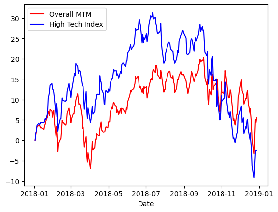

### Strategy 2: Rebalancing Buying High

Amount=5000000

Portfolio={'IBM':{'Stocks':1000000//df['IBM_Close'].iloc[0],'Rest':1000000-(1000000//df['IBM_Close'].iloc[0]*df['IBM_Close'].iloc[0])},

'MSFT':{'Stocks':1000000//df['MSFT_Close'].iloc[0],'Rest':1000000-(1000000//df['MSFT_Close'].iloc[0]*df['MSFT_Close'].iloc[0])},

'GOOG':{'Stocks':1000000//df['GOOG_Close'].iloc[0],'Rest':1000000-(1000000//df['GOOG_Close'].iloc[0]*df['GOOG_Close'].iloc[0])},

'AAPL':{'Stocks':1000000//df['AAPL_Close'].iloc[0],'Rest':1000000-(1000000//df['AAPL_Close'].iloc[0]*df['AAPL_Close'].iloc[0])},

'AMZN':{'Stocks':1000000//df['AMZN_Close'].iloc[0],'Rest':1000000-(1000000//df['AMZN_Close'].iloc[0]*df['AMZN_Close'].iloc[0])},

'META':{'Stocks':0,'Rest':0},

'NFLX':{'Stocks':0,'Rest':0},

'TSLA':{'Stocks':0,'Rest':0},

'ORCL':{'Stocks':0,'Rest':0},

'SAP':{'Stocks':0,'Rest':0}

}

Overall_MTM=[]

Overall_MTM+=[5000000]

Overall_MTM

d=[]

l=0

l1=0

names = ['IBM', 'MSFT', 'GOOG', 'AAPL', 'AMZN', 'META', 'NFLX', 'TSLA', 'ORCL', 'SAP']

Stocks=['IBM','MSFT','GOOG','AAPL','AMZN']

for i in range(1,len(df)):

s=0

l+=1

for j in names:

if j in Stocks:

mtm=((Portfolio[j]['Stocks']*df[j+'_Close'][i])+(Portfolio[j]['Rest'])+(Portfolio[j]['Stocks']*df[j+'_Dividend'][i]))

s+=mtm

Overall_MTM+=[s]

if l%5==0:

l1+=1

Percent_change={'IBM':0,'MSFT':0,"GOOG":0,'AAPL':0,'AMZN':0,'META':0,'NFLX':0, 'TSLA':0, 'ORCL':0, 'SAP':0}

for j in names:

Percent_change[j]=round(((df[j+'_Adj_Close'][i]-df[j+'_Adj_Close'][i-5])/df[j+'_Adj_Close'][i-5])*100,3)

Stocks=[i[0] for i in list(sorted(Percent_change.items(), key=lambda x: x[1]))[5:]]

for j in names:

if j in Stocks:

a=s/5

Portfolio[j]['Stocks']=a//df[j+'_Close'].iloc[i]

Portfolio[j]['Rest']=a-(a//df[j+'_Close'].iloc[i]*df[j+'_Close'].iloc[i])

else:

Portfolio[j]['Stocks']=0

Portfolio[j]['Rest']=0

df2=df.copy()

df2['High_Tech_Index']=(df2.IBM_Close+df2.MSFT_Close+df2.GOOG_Close+df2.AMZN_Close+df2.AAPL_Close+df2.META_Close+

df2.NFLX_Close+df2.TSLA_Close+df2.ORCL_Close+df2.SAP_Close)/10

df2['Overall_MTM']=Overall_MTM

df2['High_Tech_Index_Percent_Change']=[((df2['High_Tech_Index'][i]-df2['High_Tech_Index'][0])/df2['High_Tech_Index'][0])*100 if i>0 else 0

for i in range(len(df2))]

df2['Overall_MTM_Percent_Change']=[((df2['Overall_MTM'][i]-df2['Overall_MTM'][0])/df2['Overall_MTM'][0])*100 if i>0 else 0

for i in range(len(df2))]

df2.head(11)

|  | Date | IBM_Close | IBM_Adj_Close | IBM_Dividend | MSFT_Close | MSFT_Adj_Close | MSFT_Dividend | GOOG_Close | GOOG_Adj_Close | GOOG_Dividend | ... | ORCL_Close | ORCL_Adj_Close | ORCL_Dividend | SAP_Close | SAP_Adj_Close | SAP_Dividend | High_Tech_Index | Overall_MTM | High_Tech_Index_Percent_Change | Overall_MTM_Percent_Change |
| --- | --- | --- | --- | --- | --- | --- | --- | --- | --- | --- | --- | --- | --- | --- | --- | --- | --- | --- | --- | --- | --- |
| 0 | 2018-01-02 | 147.466537 | 111.800133 | 0.0 | 85.949997 | 80.391853 | 0.0 | 53.250000 | 53.250000 | 0.0 | ... | 46.630001 | 42.437176 | 0.000000 | 112.389999 | 101.210297 | 0.0 | 95.206071 | 5.000000e+06 | 0.000000 | 0.000000 |
| 1 | 2018-01-03 | 151.520081 | 114.873306 | 0.0 | 86.349998 | 80.765961 | 0.0 | 54.124001 | 54.124001 | 0.0 | ... | 47.709999 | 43.420063 | 0.000000 | 113.309998 | 102.038773 | 0.0 | 96.715158 | 5.061154e+06 | 1.585074 | 1.223084 |
| 2 | 2018-01-04 | 154.588913 | 117.199913 | 0.0 | 87.110001 | 81.476837 | 0.0 | 54.320000 | 54.320000 | 0.0 | ... | 48.180000 | 43.847794 | 0.000000 | 115.050003 | 103.605690 | 0.0 | 97.392059 | 5.103664e+06 | 2.296060 | 2.073270 |
| 3 | 2018-01-05 | 155.344162 | 117.772476 | 0.0 | 88.190002 | 82.486992 | 0.0 | 55.111500 | 55.111500 | 0.0 | ... | 48.470001 | 44.111725 | 0.000000 | 116.330002 | 104.758369 | 0.0 | 98.659801 | 5.164091e+06 | 3.627637 | 3.281811 |
| 4 | 2018-01-08 | 156.281067 | 118.482796 | 0.0 | 88.279999 | 82.571167 | 0.0 | 55.347000 | 55.347000 | 0.0 | ... | 48.980000 | 44.575863 | 0.000000 | 114.800003 | 103.380562 | 0.0 | 99.237640 | 5.187051e+06 | 4.234572 | 3.741018 |
| 5 | 2018-01-09 | 156.625244 | 118.743706 | 0.0 | 88.220001 | 82.515060 | 0.0 | 55.313000 | 55.313000 | 0.0 | ... | 49.060001 | 44.822540 | 0.191334 | 114.160004 | 102.804222 | 0.0 | 98.902174 | 5.192835e+06 | 3.882214 | 3.856703 |
| 6 | 2018-01-10 | 156.959854 | 118.997383 | 0.0 | 87.820000 | 82.140900 | 0.0 | 55.130501 | 55.130501 | 0.0 | ... | 48.799999 | 44.585003 | 0.000000 | 112.870003 | 101.642548 | 0.0 | 99.054935 | 5.210281e+06 | 4.042667 | 4.205610 |
| 7 | 2018-01-11 | 156.978973 | 119.011909 | 0.0 | 88.080002 | 82.384109 | 0.0 | 55.276001 | 55.276001 | 0.0 | ... | 48.950001 | 44.722042 | 0.000000 | 109.639999 | 98.733833 | 0.0 | 99.411899 | 5.265332e+06 | 4.417605 | 5.306635 |
| 8 | 2018-01-12 | 155.965576 | 118.243591 | 0.0 | 89.599998 | 83.805824 | 0.0 | 56.112999 | 56.112999 | 0.0 | ... | 49.509998 | 45.233669 | 0.000000 | 110.129997 | 99.175095 | 0.0 | 99.386573 | 5.308522e+06 | 4.391004 | 6.170441 |
| 9 | 2018-01-16 | 156.644363 | 118.758202 | 0.0 | 88.349998 | 82.636642 | 0.0 | 56.088001 | 56.088001 | 0.0 | ... | 49.590000 | 45.306770 | 0.000000 | 110.680000 | 99.670380 | 0.0 | 99.323353 | 5.327874e+06 | 4.324600 | 6.557474 |
| 10 | 2018-01-17 | 161.233276 | 122.237259 | 0.0 | 90.139999 | 84.310890 | 0.0 | 56.598999 | 56.598999 | 0.0 | ... | 50.270000 | 45.928036 | 0.000000 | 111.190002 | 100.129669 | 0.0 | 99.720128 | 5.366623e+06 | 4.741355 | 7.332468 |

11 rows × 35 columns

plt.plot(df2['Date'], df2['Overall_MTM_Percent_Change'],color='red' ,label='Overall MTM')

plt.plot(df2['Date'], df2['High_Tech_Index_Percent_Change'], color='blue', label='High Tech Index')

plt.xlabel('Date')

plt.legend()

plt.show()

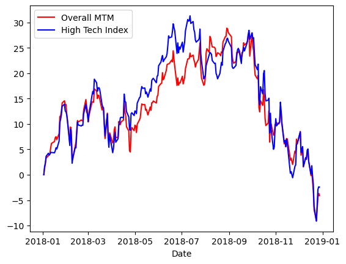

## JPY

jpy=pd.read_csv('JPY=X.csv')[['Date','Close']]

jpy.Date=pd.to_datetime(jpy.Date)

jpy.rename({'Close':'Jpy_Close'},axis=1,inplace=True)

jpy.head()

|  | Date | Jpy_Close |
| --- | --- | --- |
| 0 | 2018-01-02 | 112.769997 |
| 1 | 2018-01-03 | 112.244003 |
| 2 | 2018-01-04 | 112.607002 |
| 3 | 2018-01-05 | 112.782997 |
| 4 | 2018-01-08 | 113.153999 |

### JPY for Rebalancing Low

df3=df1.merge(jpy,how='inner',on='Date')

df3.head()

df3['Overall_MTM_Jpy']=df3.Overall_MTM*df3.Jpy_Close

df3['High_Tech_Index_Jpy']=df3.High_Tech_Index*df3.Jpy_Close

df3['High_Tech_Index_Percent_Change_Jpy']=[((df3['High_Tech_Index_Jpy'][i]-df3['High_Tech_Index_Jpy'][0])/df3['High_Tech_Index_Jpy'][0])*100 if i>0 else 0

for i in range(len(df3))]

df3['Overall_MTM_Percent_Change_Jpy']=[((df3['Overall_MTM_Jpy'][i]-df3['Overall_MTM_Jpy'][0])/df3['Overall_MTM_Jpy'][0])*100 if i>0 else 0

for i in range(len(df3))]

df3.head()

|  | Date | IBM_Close | IBM_Adj_Close | IBM_Dividend | MSFT_Close | MSFT_Adj_Close | MSFT_Dividend | GOOG_Close | GOOG_Adj_Close | GOOG_Dividend | ... | SAP_Dividend | High_Tech_Index | Overall_MTM | High_Tech_Index_Percent_Change | Overall_MTM_Percent_Change | Jpy_Close | Overall_MTM_Jpy | High_Tech_Index_Jpy | High_Tech_Index_Percent_Change_Jpy | Overall_MTM_Percent_Change_Jpy |
| --- | --- | --- | --- | --- | --- | --- | --- | --- | --- | --- | --- | --- | --- | --- | --- | --- | --- | --- | --- | --- | --- |
| 0 | 2018-01-02 | 147.466537 | 111.800133 | 0.0 | 85.949997 | 80.391853 | 0.0 | 53.250000 | 53.250000 | 0.0 | ... | 0.0 | 95.206071 | 5.000000e+06 | 0.000000 | 0.000000 | 112.769997 | 5.638500e+08 | 10736.388296 | 0.000000 | 0.000000 |
| 1 | 2018-01-03 | 151.520081 | 114.873306 | 0.0 | 86.349998 | 80.765961 | 0.0 | 54.124001 | 54.124001 | 0.0 | ... | 0.0 | 96.715158 | 5.061154e+06 | 1.585074 | 1.223084 | 112.244003 | 5.680842e+08 | 10855.696440 | 1.111250 | 0.750948 |
| 2 | 2018-01-04 | 154.588913 | 117.199913 | 0.0 | 87.110001 | 81.476837 | 0.0 | 54.320000 | 54.320000 | 0.0 | ... | 0.0 | 97.392059 | 5.103664e+06 | 2.296060 | 2.073270 | 112.607002 | 5.747082e+08 | 10967.027794 | 2.148204 | 1.925736 |
| 3 | 2018-01-05 | 155.344162 | 117.772476 | 0.0 | 88.190002 | 82.486992 | 0.0 | 55.111500 | 55.111500 | 0.0 | ... | 0.0 | 98.659801 | 5.164091e+06 | 3.627637 | 3.281811 | 112.782997 | 5.824216e+08 | 11127.148063 | 3.639583 | 3.293718 |
| 4 | 2018-01-08 | 156.281067 | 118.482796 | 0.0 | 88.279999 | 82.571167 | 0.0 | 55.347000 | 55.347000 | 0.0 | ... | 0.0 | 99.237640 | 5.187051e+06 | 4.234572 | 3.741018 | 113.153999 | 5.869356e+08 | 11229.135874 | 4.589510 | 4.094274 |

5 rows × 40 columns

plt.plot(df3['Date'], df3['Overall_MTM_Percent_Change_Jpy'],color='red' ,label='Overall MTM Jpy')

plt.plot(df3['Date'], df3['High_Tech_Index_Percent_Change_Jpy'], color='blue', label='High Tech Index Jpy')

plt.xlabel('Date')

plt.legend()

plt.show()

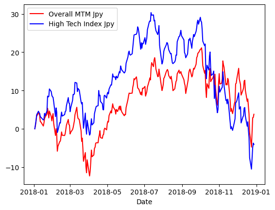

### Jpy for Rebalancing High

df4=df2.merge(jpy,how='inner',on='Date')

df4.head()

|  | Date | IBM_Close | IBM_Adj_Close | IBM_Dividend | MSFT_Close | MSFT_Adj_Close | MSFT_Dividend | GOOG_Close | GOOG_Adj_Close | GOOG_Dividend | ... | ORCL_Adj_Close | ORCL_Dividend | SAP_Close | SAP_Adj_Close | SAP_Dividend | High_Tech_Index | Overall_MTM | High_Tech_Index_Percent_Change | Overall_MTM_Percent_Change | Jpy_Close |
| --- | --- | --- | --- | --- | --- | --- | --- | --- | --- | --- | --- | --- | --- | --- | --- | --- | --- | --- | --- | --- | --- |
| 0 | 2018-01-02 | 147.466537 | 111.800133 | 0.0 | 85.949997 | 80.391853 | 0.0 | 53.250000 | 53.250000 | 0.0 | ... | 42.437176 | 0.0 | 112.389999 | 101.210297 | 0.0 | 95.206071 | 5.000000e+06 | 0.000000 | 0.000000 | 112.769997 |
| 1 | 2018-01-03 | 151.520081 | 114.873306 | 0.0 | 86.349998 | 80.765961 | 0.0 | 54.124001 | 54.124001 | 0.0 | ... | 43.420063 | 0.0 | 113.309998 | 102.038773 | 0.0 | 96.715158 | 5.061154e+06 | 1.585074 | 1.223084 | 112.244003 |
| 2 | 2018-01-04 | 154.588913 | 117.199913 | 0.0 | 87.110001 | 81.476837 | 0.0 | 54.320000 | 54.320000 | 0.0 | ... | 43.847794 | 0.0 | 115.050003 | 103.605690 | 0.0 | 97.392059 | 5.103664e+06 | 2.296060 | 2.073270 | 112.607002 |
| 3 | 2018-01-05 | 155.344162 | 117.772476 | 0.0 | 88.190002 | 82.486992 | 0.0 | 55.111500 | 55.111500 | 0.0 | ... | 44.111725 | 0.0 | 116.330002 | 104.758369 | 0.0 | 98.659801 | 5.164091e+06 | 3.627637 | 3.281811 | 112.782997 |
| 4 | 2018-01-08 | 156.281067 | 118.482796 | 0.0 | 88.279999 | 82.571167 | 0.0 | 55.347000 | 55.347000 | 0.0 | ... | 44.575863 | 0.0 | 114.800003 | 103.380562 | 0.0 | 99.237640 | 5.187051e+06 | 4.234572 | 3.741018 | 113.153999 |

5 rows × 36 columns

df4['Overall_MTM_Jpy']=df4.Overall_MTM*df4.Jpy_Close

df4['High_Tech_Index_Jpy']=df4.High_Tech_Index*df4.Jpy_Close

df4['High_Tech_Index_Percent_Change_Jpy']=[((df4['High_Tech_Index_Jpy'][i]-df4['High_Tech_Index_Jpy'][0])/df4['High_Tech_Index_Jpy'][0])*100 if i>0 else 0

for i in range(len(df4))]

df4['Overall_MTM_Percent_Change_Jpy']=[((df4['Overall_MTM_Jpy'][i]-df4['Overall_MTM_Jpy'][0])/df4['Overall_MTM_Jpy'][0])*100 if i>0 else 0

for i in range(len(df4))]

df4.head()

|  | Date | IBM_Close | IBM_Adj_Close | IBM_Dividend | MSFT_Close | MSFT_Adj_Close | MSFT_Dividend | GOOG_Close | GOOG_Adj_Close | GOOG_Dividend | ... | SAP_Dividend | High_Tech_Index | Overall_MTM | High_Tech_Index_Percent_Change | Overall_MTM_Percent_Change | Jpy_Close | Overall_MTM_Jpy | High_Tech_Index_Jpy | High_Tech_Index_Percent_Change_Jpy | Overall_MTM_Percent_Change_Jpy |
| --- | --- | --- | --- | --- | --- | --- | --- | --- | --- | --- | --- | --- | --- | --- | --- | --- | --- | --- | --- | --- | --- |
| 0 | 2018-01-02 | 147.466537 | 111.800133 | 0.0 | 85.949997 | 80.391853 | 0.0 | 53.250000 | 53.250000 | 0.0 | ... | 0.0 | 95.206071 | 5.000000e+06 | 0.000000 | 0.000000 | 112.769997 | 5.638500e+08 | 10736.388296 | 0.000000 | 0.000000 |
| 1 | 2018-01-03 | 151.520081 | 114.873306 | 0.0 | 86.349998 | 80.765961 | 0.0 | 54.124001 | 54.124001 | 0.0 | ... | 0.0 | 96.715158 | 5.061154e+06 | 1.585074 | 1.223084 | 112.244003 | 5.680842e+08 | 10855.696440 | 1.111250 | 0.750948 |
| 2 | 2018-01-04 | 154.588913 | 117.199913 | 0.0 | 87.110001 | 81.476837 | 0.0 | 54.320000 | 54.320000 | 0.0 | ... | 0.0 | 97.392059 | 5.103664e+06 | 2.296060 | 2.073270 | 112.607002 | 5.747082e+08 | 10967.027794 | 2.148204 | 1.925736 |
| 3 | 2018-01-05 | 155.344162 | 117.772476 | 0.0 | 88.190002 | 82.486992 | 0.0 | 55.111500 | 55.111500 | 0.0 | ... | 0.0 | 98.659801 | 5.164091e+06 | 3.627637 | 3.281811 | 112.782997 | 5.824216e+08 | 11127.148063 | 3.639583 | 3.293718 |
| 4 | 2018-01-08 | 156.281067 | 118.482796 | 0.0 | 88.279999 | 82.571167 | 0.0 | 55.347000 | 55.347000 | 0.0 | ... | 0.0 | 99.237640 | 5.187051e+06 | 4.234572 | 3.741018 | 113.153999 | 5.869356e+08 | 11229.135874 | 4.589510 | 4.094274 |

5 rows × 40 columns

plt.plot(df4['Date'], df4['Overall_MTM_Percent_Change_Jpy'],color='red' ,label='Overall MTM Jpy')

plt.plot(df4['Date'], df4['High_Tech_Index_Percent_Change_Jpy'], color='blue', label='High Tech Index Jpy')

plt.xlabel('Date')

plt.legend()

plt.show()

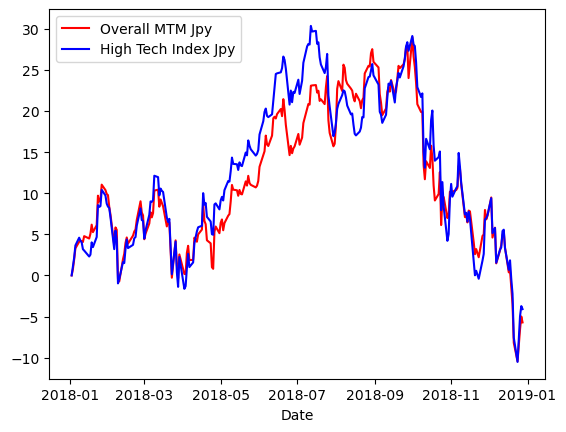

## Finding Optimal Days

### For Rebalancing Low

num_of_days_low={}

for k in range(1,21):

Portfolio={'IBM':{'Stocks':1000000//df['IBM_Close'].iloc[0],'Rest':1000000-(1000000//df['IBM_Close'].iloc[0]*df['IBM_Close'].iloc[0])},

'MSFT':{'Stocks':1000000//df['MSFT_Close'].iloc[0],'Rest':1000000-(1000000//df['MSFT_Close'].iloc[0]*df['MSFT_Close'].iloc[0])},

'GOOG':{'Stocks':1000000//df['GOOG_Close'].iloc[0],'Rest':1000000-(1000000//df['GOOG_Close'].iloc[0]*df['GOOG_Close'].iloc[0])},

'AAPL':{'Stocks':1000000//df['AAPL_Close'].iloc[0],'Rest':1000000-(1000000//df['AAPL_Close'].iloc[0]*df['AAPL_Close'].iloc[0])},

'AMZN':{'Stocks':1000000//df['AMZN_Close'].iloc[0],'Rest':1000000-(1000000//df['AMZN_Close'].iloc[0]*df['AMZN_Close'].iloc[0])},

'META':{'Stocks':0,'Rest':0},

'NFLX':{'Stocks':0,'Rest':0},

'TSLA':{'Stocks':0,'Rest':0},

'ORCL':{'Stocks':0,'Rest':0},

'SAP':{'Stocks':0,'Rest':0}

}

Overall_MTM=[]

Overall_MTM+=[5000000]

Overall_MTM

d=[]

l=0

names = ['IBM', 'MSFT', 'GOOG', 'AAPL', 'AMZN', 'META', 'NFLX', 'TSLA', 'ORCL', 'SAP']

Stocks=['IBM','MSFT','GOOG','AAPL','AMZN']

for i in range(1,len(df)):

s=0

l+=1

for j in names:

if j in Stocks:

mtm=((Portfolio[j]['Stocks']*df[j+'_Close'][i])+(Portfolio[j]['Rest'])+(Portfolio[j]['Stocks']*df[j+'_Dividend'][i]))

s+=mtm

Overall_MTM+=[s]

if l%k==0:

Percent_change={'IBM':0,'MSFT':0,"GOOG":0,'AAPL':0,'AMZN':0,'META':0,'NFLX':0, 'TSLA':0, 'ORCL':0, 'SAP':0}

for j in names:

Percent_change[j]=round(((df[j+'_Adj_Close'][i]-df[j+'_Adj_Close'][i-k])/df[j+'_Adj_Close'][i-k])*100,3)

Stocks=[i[0] for i in list(sorted(Percent_change.items(), key=lambda x: x[1]))[:5]]

for j in names:

if j in Stocks:

a=s/5

Portfolio[j]['Stocks']=a//df[j+'_Close'].iloc[i]

Portfolio[j]['Rest']=a-(a//df[j+'_Close'].iloc[i]*df[j+'_Close'].iloc[i])

else:

Portfolio[j]['Stocks']=0

Portfolio[j]['Rest']=0

num_of_days_low[k]=Overall_MTM[-1]

num_of_days_low

sorted(num_of_days_low.items(), key=lambda x: x[1],reverse=True)

```
[(8, 5800316.574886001),
 (4, 5696129.132214997),
 (15, 5505203.745729),
 (16, 5376726.374153001),
 (10, 5328995.491147998),
 (13, 5300437.997256002),
 (5, 5280225.716942002),
 (14, 5262497.468432997),
 (9, 5245651.781037996),
 (18, 5161078.645026998),
 (20, 5157498.490628),
 (2, 5152542.704268984),
 (17, 4960983.358823003),
 (3, 4910630.535708999),
 (19, 4906928.345644),
 (6, 4875185.745360007),
 (1, 4843867.206204987),
 (7, 4834270.712735999),
 (11, 4724167.880639),
 (12, 4669853.790402)]
```

plt.plot(num_of_days_low.keys(),num_of_days_low.values(),color='red' ,label='MTM')

plt.ylabel('MTM')

plt.xlabel('No. of Days')

plt.legend()

plt.show()

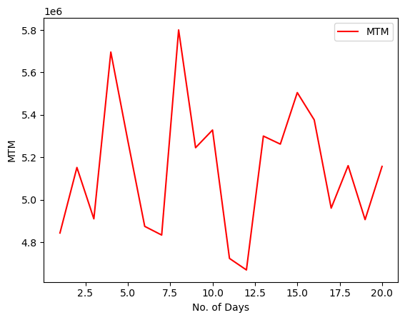

#### From the plot and data we can see having the strategy for 8 days offers highest profit at the end of the year

### For Rebalancing High

num_of_days_high={}

for k in range(1,21):

Portfolio={'IBM':{'Stocks':1000000//df['IBM_Close'].iloc[0],'Rest':1000000-(1000000//df['IBM_Close'].iloc[0]*df['IBM_Close'].iloc[0])},

'MSFT':{'Stocks':1000000//df['MSFT_Close'].iloc[0],'Rest':1000000-(1000000//df['MSFT_Close'].iloc[0]*df['MSFT_Close'].iloc[0])},

'GOOG':{'Stocks':1000000//df['GOOG_Close'].iloc[0],'Rest':1000000-(1000000//df['GOOG_Close'].iloc[0]*df['GOOG_Close'].iloc[0])},

'AAPL':{'Stocks':1000000//df['AAPL_Close'].iloc[0],'Rest':1000000-(1000000//df['AAPL_Close'].iloc[0]*df['AAPL_Close'].iloc[0])},

'AMZN':{'Stocks':1000000//df['AMZN_Close'].iloc[0],'Rest':1000000-(1000000//df['AMZN_Close'].iloc[0]*df['AMZN_Close'].iloc[0])},

'META':{'Stocks':0,'Rest':0},

'NFLX':{'Stocks':0,'Rest':0},

'TSLA':{'Stocks':0,'Rest':0},

'ORCL':{'Stocks':0,'Rest':0},

'SAP':{'Stocks':0,'Rest':0}

}

Overall_MTM=[]

Overall_MTM+=[5000000]

Overall_MTM

d=[]

l=0

names = ['IBM', 'MSFT', 'GOOG', 'AAPL', 'AMZN', 'META', 'NFLX', 'TSLA', 'ORCL', 'SAP']

Stocks=['IBM','MSFT','GOOG','AAPL','AMZN']

for i in range(1,len(df)):

s=0

l+=1

for j in names:

if j in Stocks:

mtm=((Portfolio[j]['Stocks']*df[j+'_Close'][i])+(Portfolio[j]['Rest'])+(Portfolio[j]['Stocks']*df[j+'_Dividend'][i]))

s+=mtm

Overall_MTM+=[s]

if l%k==0:

Percent_change={'IBM':0,'MSFT':0,"GOOG":0,'AAPL':0,'AMZN':0,'META':0,'NFLX':0, 'TSLA':0, 'ORCL':0, 'SAP':0}

for j in names:

Percent_change[j]=round(((df[j+'_Adj_Close'][i]-df[j+'_Adj_Close'][i-k])/df[j+'_Adj_Close'][i-k])*100,3)

Stocks=[i[0] for i in list(sorted(Percent_change.items(), key=lambda x: x[1]))[5:]]

for j in names:

if j in Stocks:

a=s/5

Portfolio[j]['Stocks']=a//df[j+'_Close'].iloc[i]

Portfolio[j]['Rest']=a-(a//df[j+'_Close'].iloc[i]*df[j+'_Close'].iloc[i])

else:

Portfolio[j]['Stocks']=0

Portfolio[j]['Rest']=0

num_of_days_high[k]=Overall_MTM[-1]

num_of_days_high

sorted(num_of_days_high.items(), key=lambda x: x[1],reverse=True)

```
[(11, 5411684.935847001),
 (12, 5364502.529599),
 (1, 5299828.727711988),
 (7, 5179150.291661998),
 (6, 5167044.262388999),
 (3, 5153516.031086007),
 (19, 5011450.712515001),
 (2, 4958776.0632380005),
 (9, 4885695.824092999),
 (17, 4873197.3015279975),
 (10, 4851730.574808005),
 (5, 4795556.381297003),
 (13, 4766989.943588),
 (20, 4753297.659857997),
 (14, 4706059.199445002),
 (18, 4655772.569566),
 (16, 4558402.0800330015),
 (8, 4447272.829117),
 (15, 4440866.908009),
 (4, 4421802.781006993)]
```

plt.plot(num_of_days_high.keys(),num_of_days_high.values(),color='red' ,label='MTM')

plt.ylabel('MTM')

plt.xlabel('No. of Days')

plt.legend()

plt.show()

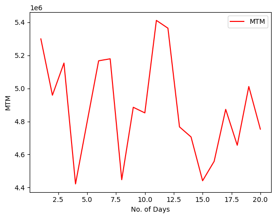

#### From the plot and data we can see having the strategy for 11 days offers highest profit at the end of the year.